# Cohesion Index Calculation

Johann Delcourt, Noam Miller, Iain Couzin, & Simon Garnier

March 14, 2017

# 1 Introduction

This note explains the steps to calculate a new index that estimates the cohesion of a group of individuals in a radial arm maze (note that this index can also be used for all types of mazes or arenas divided into distinct zones). This index is an alternative to the classical methods used to measure group cohesion based on topological and metric relationships between individuals (see [1]). These methods cannot be used reliably with a radial arm maze because individuals located in adjacent arms might be spatially close, yet incapable of interacting directly with each other.

The new cohesion index $I_c$ introduced here measures the ability of individuals to form cohesive groups in a radial arm maze. Its value is maximal (i.e. $I_c=1$) when all the animals are located in a single zone of the maze; it is minimal (i.e. $I_c=0$) when the animals are distributed uniformly between all the zones of the maze.

Back to top

# 2 Definition of $I_c$

Let $f_i$ be the number of individuals in each zone $z_i$ of the radial arm maze. For a maze with $Z$ zones, the Euclidean distance $D_c$ between all $f_i$ can be calculated as:

$$D_c = \sqrt{\sum_{i=1}^{Z}(f_i)^2}$$

Let $D_{min}$ be the value of $D_c$ for the least cohesive distribution possible of individuals between the zones of the maze (i.e. homogenous distribution of the individuals), and $N$ the total number of individuals in the maze. Therefore the cohesion index $I_c$ can be calculated as:

$$I_c = \frac{D_c - D_{min}}{N - D_{min}}$$

Back to top

# 3 Calculating $D_{min}$

## 3.1 Partitions

$D_{min}$ depends on how $N$ individuals can be partitioned between $Z$ zones in the maze.

In number theory and combinatorics, a partition of a positive integer $x$, also called an integer partition, is a way of writing $x$ as a sum of positive integers [2–4]. Two sums that differ only in the order of their summands are considered to be the same partition. The number of distinct partitions of $x$, without regard to the ordering of the terms, is defined as $P(x)$.

For example, 4 can be partitioned in five distinct ways;

$$4;\quad 3 + 1;\quad 2 + 2;\quad 2 + 1 + 1;\quad 1 + 1 + 1 + 1$$

Thus, the number of partitions $P(4) = 5$. As partitions are not order-dependent, $1 + 3$ is the same partition as $3 + 1$ for instance. It is conventional to write the parts of a partition in descending order.

In `R` [5], the `partitions` package [6] can be used to obtain $P(x)$ (with the function `P`) as well as all the possible partitions of $x$ (with the function `parts`). For instance, for $x=4$:

```r
if (!require(partitions)) {
  install.packages("partitions")
  library(partitions)
}
x <- 4
P(x)
```

```
## [1] 5
```

```r
parts(x)
```

```
##
## [1,] 4 3 2 2 1
## [2,] 0 1 2 1 1
## [3,] 0 0 0 1 1
## [4,] 0 0 0 0 1
```

(with each column corresponding to a different partition of $x$).

Back to top

## 3.2 Partitions when $Z \geq N$

In the radial maze context, if the number of zones $Z$ is superior or equal to the number of individuals $N$, all the possible partitions of $N$ can be observed, and notably the more distributed partitions where each individual is alone in a zone). The number of partitions and the partitions themselves can therefore be obtained as described above.

Back to top

## 3.3 Partitions when $Z < N$

If the number of zones $Z$ is inferior to the number of individuals $N$, then not all partitions can be observed. For instance, in the case of $N=4$ and $Z=3$, it is impossible to observe the partition $1+1+1+1$. The total number of observable partitions in this case is therefore $P(4, 3) = 4$.

In `R`, the number of restricted partitions (i.e. the number of partitions that can be observed given $N$ and $Z$ in our case) can be calculated using the function `R` in the `partitions` package. For instance, for $N=4$ and $Z=3$:

```r
N <- 4
Z <- 3

R(Z, N, include.zero = TRUE)
```

```
## [1] 4
```

And the restricted partitions can be obtained with the function `restrictedparts` as follows:

```r
restrictedparts(N, Z)
```

```
##
## [1,] 4 3 2 2
## [2,] 0 1 2 1
## [3,] 0 0 0 1
```

(with each column corresponding to a different partition of $N$ in $Z$ zones).

The Supplementary Table 1 below shows the number of restricted partitions for various values of $N$ and $Z$.

**Supplementary Table 1:** Partition number as a function of the number of individuals $N$ and the number of zones $Z$. In our experiment, the partition number $P(10,7)$ is $38$.

|  | Z=1 | Z=2 | Z=3 | Z=4 | Z=5 | Z=6 | Z=7 | Z=8 | Z=9 | Z=10 |
| --- | --- | --- | --- | --- | --- | --- | --- | --- | --- | --- |
| **N=1** | 1 | 1 | 1 | 1 | 1 | 1 | 1 | 1 | 1 | 1 |
| **N=2** | 1 | 2 | 2 | 2 | 2 | 2 | 2 | 2 | 2 | 2 |
| **N=3** | 1 | 2 | 3 | 3 | 3 | 3 | 3 | 3 | 3 | 3 |
| **N=4** | 1 | 3 | 4 | 5 | 5 | 5 | 5 | 5 | 5 | 5 |
| **N=5** | 1 | 3 | 5 | 6 | 7 | 7 | 7 | 7 | 7 | 7 |
| **N=6** | 1 | 4 | 7 | 9 | 10 | 11 | 11 | 11 | 11 | 11 |
| **N=7** | 1 | 4 | 8 | 11 | 13 | 14 | 15 | 15 | 15 | 15 |
| **N=8** | 1 | 5 | 10 | 15 | 18 | 20 | 21 | 22 | 22 | 22 |
| **N=9** | 1 | 5 | 12 | 18 | 23 | 26 | 28 | 29 | 30 | 30 |
| **N=10** | 1 | 6 | 14 | 23 | 30 | 35 | 38 | 40 | 41 | 42 |

Back to top

## 3.4 $D_{min}$ as a function of $N$ and $Z$

With `R`, $D_{min}$ can be easily calculated for a given $N$ and $Z$ as follows (here $N=4$ and $Z=3$, as before):

```r
N <- 4
Z <- 3

partitions <- restrictedparts(N, Z)
Dc <- sqrt(apply(partitions ^ 2, 2, sum))
min(Dc)
```

```
## [1] 2.44949
```

The Supplementary Table 2 below shows the values of $D_{min}$ for various values of $N$ and $Z$.

|  | Z=1 | Z=2 | Z=3 | Z=4 | Z=5 | Z=6 | Z=7 | Z=8 | Z=9 | Z=10 |
| --- | --- | --- | --- | --- | --- | --- | --- | --- | --- | --- |
| **N=1** | 1 | 1 | 1 | 1 | 1 | 1 | 1 | 1 | 1 | 1 |
| **N=2** | 1 | $\sqrt{2}$ | $\sqrt{2}$ | $\sqrt{2}$ | $\sqrt{2}$ | $\sqrt{2}$ | $\sqrt{2}$ | $\sqrt{2}$ | $\sqrt{2}$ | $\sqrt{2}$ |
| **N=3** | 1 | $\sqrt{5}$ | $\sqrt{3}$ | $\sqrt{3}$ | $\sqrt{3}$ | $\sqrt{3}$ | $\sqrt{3}$ | $\sqrt{3}$ | $\sqrt{3}$ | $\sqrt{3}$ |
| **N=4** | 1 | $\sqrt{8}$ | $\sqrt{6}$ | 2 | 2 | 2 | 2 | 2 | 2 | 2 |
| **N=5** | 1 | $\sqrt{13}$ | 3 | $\sqrt{7}$ | $\sqrt{5}$ | $\sqrt{5}$ | $\sqrt{5}$ | $\sqrt{5}$ | $\sqrt{5}$ | $\sqrt{5}$ |
| **N=6** | 1 | $\sqrt{18}$ | $\sqrt{12}$ | $\sqrt{10}$ | $\sqrt{8}$ | $\sqrt{6}$ | $\sqrt{6}$ | $\sqrt{6}$ | $\sqrt{6}$ | $\sqrt{6}$ |
| **N=7** | 1 | 5 | $\sqrt{17}$ | $\sqrt{13}$ | $\sqrt{11}$ | 3 | $\sqrt{7}$ | $\sqrt{7}$ | $\sqrt{7}$ | $\sqrt{7}$ |
| **N=8** | 1 | $\sqrt{32}$ | $\sqrt{22}$ | 4 | $\sqrt{14}$ | $\sqrt{12}$ | $\sqrt{10}$ | $\sqrt{8}$ | $\sqrt{8}$ | $\sqrt{8}$ |
| **N=9** | 1 | $\sqrt{41}$ | $\sqrt{27}$ | $\sqrt{21}$ | $\sqrt{17}$ | $\sqrt{15}$ | $\sqrt{13}$ | $\sqrt{11}$ | 3 | 3 |
| **N=10** | 1 | $\sqrt{50}$ | $\sqrt{34}$ | $\sqrt{26}$ | $\sqrt{20}$ | $\sqrt{18}$ | 4 | $\sqrt{14}$ | $\sqrt{12}$ | $\sqrt{10}$ |

Back to top

# 4 Calculating $I_c$ with `R`

For a same number of individuals, $I_c$ values can be different if the number of zones varies, but $I_c$ values are always between 0 (worst group cohesion possible) and 1 (best group cohesion possible). When $Z \leq N$, $D_{min}$ increases as $Z$ decreases. In our experiment, with 7 zones and 10 fish, the partition number $P(10,7)$ is 38, and not 42 as in $P(10,10)$ or $P(10,12)$ for example; as a consequence and $D_c$ varies between $D_{max} = 10$ and $D_{min} = 4$.

For convenience, we provide with our study a `R` package - called `projectRadial` containing a function - called `Ic` - for computing $I_c$ for any observed partitions of fish in radial arm mazes with any arbitrary number of arms. `Ic` takes a single input, which should be a data frame containing the number of animals in each zone of the radial arm maze. The data frame should be organized as follows: each column must correspond to a zone of the radial arm maze and each row must correspond to a different observation.

```r
# Install and load the 'projecRadial' package
if (!require(pacman)) {
  install.packages("pacman")
  library(partitions)
}
```

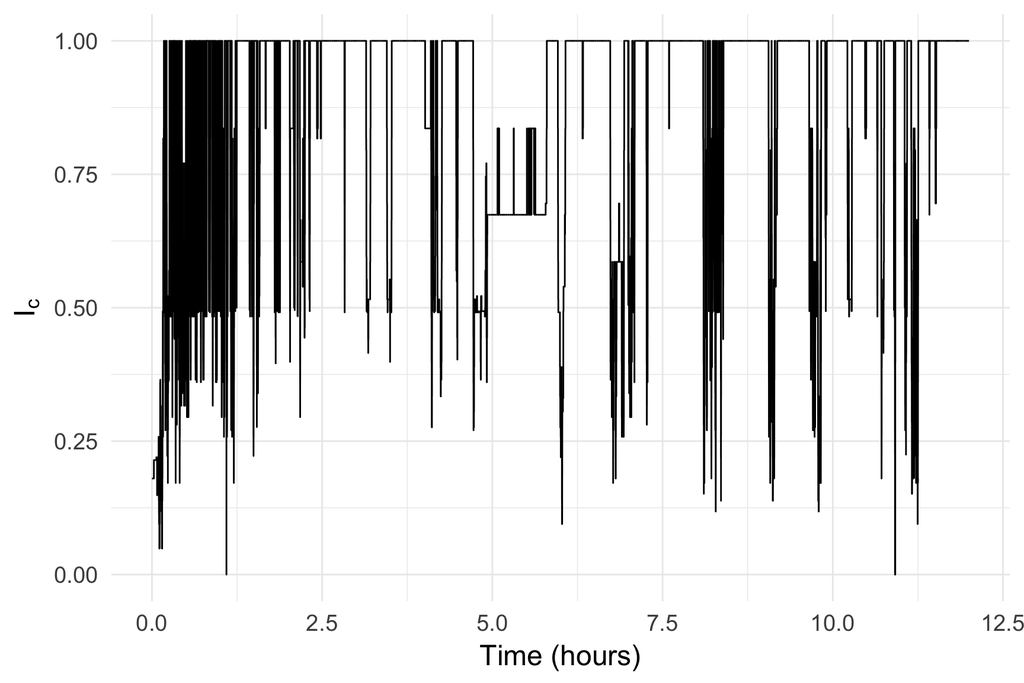

```r
p_load_gh("sjmgarnier/projectRadial")


# Calculate Ic with data provided in the 'projecRadial' package
data_path <- system.file("extdata", "sample_data.csv", package = "projectRadial")
dat <- read.csv(data_path)

dat$Ic <- Ic(dat[, 2:7])


# Plot
if (!require(ggplot2)) {
  install.packages("ggplot2")
  library(ggplot2)
}
ggplot(dat, aes(x = TimeInHours, y = Ic)) +
  geom_line() +
  xlab("Time (hours)") +
  ylab(bquote(I[c])) +
  theme_minimal(base_size = 18)
```

Back to top

# References

1. Delcourt J, Poncin P. Shoals and schools: back to the heuristic definitions and quantitative references. Reviews in fish biology and fisheries. 2012;22: 595–619. doi:10.1007/s11160-012-9260-z

2. Andrews GE. The Theory of Partitions [Internet]. Cambridge University Press; 1998. Available: https://market.android.com/details?id=book-Sp7z9sK7RNkC

3. Nathanson M. Partitions with parts in a finite set. Proceedings of the American Mathematical Society American Mathematical Society. ams.org; 2000;128: 1269–1273. Available: http://www.ams.org/proc/2000-128-05/S0002-9939-00-05606-9/

4. Andrews GE, Eriksson K. Integer Partitions [Internet]. Cambridge University Press; 2004. Available: https://market.android.com/details?id=book-_5gsjNr0lWAC

5. R Core Team. R: A language and environment for statistical computing [Internet]. Vienna, Austria: R Foundation for Statistical Computing; 2016. Available: https://www.R-project.org/

6. Hankin RKS. Additive integer partitions in r. Journal of Statistical Software, Code Snippets. 2006;16.